# Taipei accident analysis

2019/7/25

#### 108夏季學院DSP第6組-台北交通

組員: [黃科銓](https://kevinhuang102888.github.io/kevinhuang/week3/final%20project/taipei_accident) [楊岳錩](https://wilson1304983.github.io/666666/week3/final.html) [胡煜欣](https://cinnyhu.github.io/Class/Week3/wwww.html)

## 概論

我們在**臺北市資料大平台**裡，找到一份有趣的資料——「交通事故資訊」，於是想從這份資料，探究*什麼樣的人比較容易發生交通事故(who)*、*什麼的時段比較容易發生交通事故(when)*以及*什麼區域最容易發生交通事故(where)*等三個問題，目前這頁網站主要討論第二個問題，想以「時段」的角度看臺北市交通事故的問題，探討每日的事故數和節假日是否相關。

## 資料介紹

此資料來自**臺北市資料大平台**，以「107年-臺北市A1及A2類交通事故明細.csv」此資料為主要分析，裡面的column有「發生年、發生月、發生日、發生時 發生分、處理別、區序、肇事地點、死亡人數、受傷人數、當事人序、車種、性別、年齡、受傷程度、天候、速限、道路型態以及事故位置」，而總資料數有50330筆。

[臺北市交通事故](https://data.taipei/#/dataset/detail?id=2f238b4f-1b27-4085-93e9-d684ef0e2735)

## Code

1.解壓,讀數據

```r
#解壓
library(tidyverse)
library(lubridate)
library(scales)
#轉成int
a <- read_csv("107jiaotong.csv",col_types = cols(
  發生年 = col_integer(),
  發生月 = col_integer(),
  發生日 = col_integer(),
  發生時 = col_integer(),
  發生分 = col_integer(),
  處理別 = col_integer(),
  區序 = col_character(),
  肇事地點 = col_character(),
  死亡人數 = col_integer(),
  受傷人數 = col_integer(),
  當事人序 = col_integer(),
  車種 = col_character(),
  性別 = col_integer(),
  年齡 = col_integer(),
  受傷程度 = col_integer(),
  `4天候` = col_integer(),
  `7速限` = col_integer(),
  `8道路型態` = col_integer(),
  `9事故位置` = col_integer()
), locale = locale(encoding = "BIG5"))
```

2.整理

- 先按月篩,再按日篩

```r
#數據提取
v=vector(mode="integer",length=31)
b<-filter(a,發生月==1)
for(j in 1:31)
{
  d = filter(b, 發生日 == j)
  v[j]<-count(d)
}
s1 <- tibble(date=ymd(20180101:20180131),case=as.integer(v[1:31]))

v=vector(mode="integer",length=28)
b<-filter(a,發生月==2)
for(j in 1:28)
{
  d = filter(b, 發生日 == j)
  v[j]<-count(d)
}
s2 <- tibble(date=ymd(20180201:20180228),case=as.integer(v[1:28]))

v=vector(mode="integer",length=31)
b<-filter(a,發生月==3)
for(j in 1:31)
{
  d = filter(b, 發生日 == j)
  v[j]<-count(d)
}
s3 <- tibble(date=ymd(20180301:20180331),case=as.integer(v[1:31]))

v=vector(mode="integer",length=30)
b<-filter(a,發生月==4)
for(j in 1:30)
{
  d = filter(b, 發生日 == j)
  v[j]<-count(d)
}
s4 <- tibble(date=ymd(20180401:20180430),case=as.integer(v[1:30]))

v=vector(mode="integer",length=31)
b<-filter(a,發生月==5)
for(j in 1:31)
{
  d = filter(b, 發生日 == j)
  v[j]<-count(d)
}
s5 <- tibble(date=ymd(20180501:20180531),case=as.integer(v[1:31]))

v=vector(mode="integer",length=30)
b<-filter(a,發生月==6)
for(j in 1:30)
{
  d = filter(b, 發生日 == j)
  v[j]<-count(d)
}
s6 <- tibble(date=ymd(20180601:20180630),case=as.integer(v[1:30]))

v=vector(mode="integer",length=31)
b<-filter(a,發生月==7)
for(j in 1:31)
{
  d = filter(b, 發生日 == j)
  v[j]<-count(d)
}
s7 <- tibble(date=ymd(20180701:20180731),case=as.integer(v[1:31]))

v=vector(mode="integer",length=31)
b<-filter(a,發生月==8)
for(j in 1:31)
{
  d = filter(b, 發生日 == j)
  v[j]<-count(d)
}
s8 <- tibble(date=ymd(20180801:20180831),case=as.integer(v[1:31]))

v=vector(mode="integer",length=30)
b<-filter(a,發生月==9)
for(j in 1:30)
{
  d = filter(b, 發生日 == j)
  v[j]<-count(d)
}
s9 <- tibble(date=ymd(20180901:20180930),case=as.integer(v[1:30]))

v=vector(mode="integer",length=31)
b<-filter(a,發生月==10)
for(j in 1:31)
{
  d = filter(b, 發生日 == j)
  v[j]<-count(d)
}
s10 <- tibble(date=ymd(20181001:20181031),case=as.integer(v[1:31]))

v=vector(mode="integer",length=31)
b<-filter(a,發生月==11)
for(j in 1:30)
{
  d = filter(b, 發生日 == j)
  v[j]<-count(d)
}
s11 <- tibble(date=ymd(20181101:20181130),case=as.integer(v[1:30]))

v=vector(mode="integer",length=31)
b<-filter(a,發生月==12)
for(j in 1:31)
{
  d = filter(b, 發生日 == j)
  v[j]<-count(d)
}
s12 <- tibble(date=ymd(20181201:20181231),case=as.integer(v[1:31]))
#合併
s<-(s1%>%
      bind_rows(s2)%>%
      bind_rows(s3)%>%
      bind_rows(s4)%>%
      bind_rows(s5)%>%
      bind_rows(s6)%>%
      bind_rows(s7)%>%
      bind_rows(s8)%>%
      bind_rows(s9)%>%
      bind_rows(s10)%>%
      bind_rows(s11)%>%
      bind_rows(s12))
```

3.畫圖

*全年案數

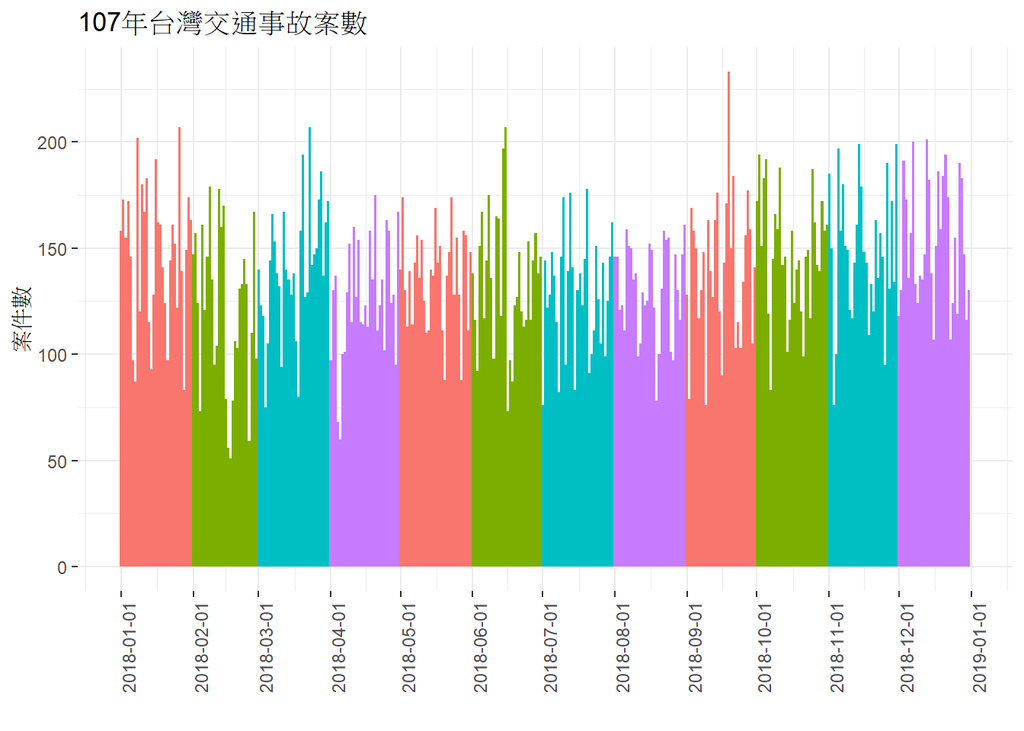

```r
#畫條形圖
ggplot()+geom_bar(data=s1,aes(x=date,y=case),stat = "identity",fill =hue_pal()(4)[1], width = 1)+geom_bar(data=s2,aes(x=date,y=case),stat = "identity",fill =hue_pal()(4)[2], width = 1)+geom_bar(data=s3,aes(x=date,y=case),stat = "identity",fill =hue_pal()(4)[3], width = 1)+geom_bar(data=s4,aes(x=date,y=case),stat = "identity",fill =hue_pal()(4)[4], width = 1)+labs(title="107年台灣交通事故案數",x="",y="案件數") +theme_bw()+theme(panel.border = element_blank())+geom_bar(data=s5,aes(x=date,y=case),stat = "identity",fill =hue_pal()(4)[1], width = 1)+geom_bar(data=s6,aes(x=date,y=case),stat = "identity",fill =hue_pal()(4)[2], width = 1)+geom_bar(data=s7,aes(x=date,y=case),stat = "identity",fill =hue_pal()(4)[3], width = 1)+geom_bar(data=s8,aes(x=date,y=case),stat = "identity",fill =hue_pal()(4)[4], width = 1)+geom_bar(data=s9,aes(x=date,y=case),stat = "identity",fill =hue_pal()(4)[1], width = 1)+geom_bar(data=s10,aes(x=date,y=case),stat = "identity",fill =hue_pal()(4)[2], width = 1)+geom_bar(data=s11,aes(x=date,y=case),stat = "identity",fill =hue_pal()(4)[3], width = 1)+geom_bar(data=s12,aes(x=date,y=case),stat = "identity",fill =hue_pal()(4)[4], width = 1)+scale_x_date(date_breaks = "1 month")+ theme(axis.text.x = element_text(angle = 90))
```

- 1~4月案數

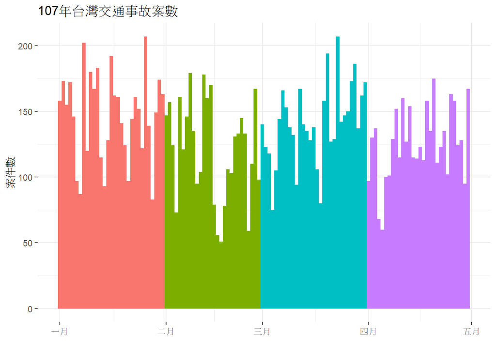

```r
ggplot()+geom_bar(data=s1,aes(x=date,y=case),stat = "identity",fill =hue_pal()(4)[1], width = 1)+geom_bar(data=s2,aes(x=date,y=case),stat = "identity",fill =hue_pal()(4)[2], width = 1)+geom_bar(data=s3,aes(x=date,y=case),stat = "identity",fill =hue_pal()(4)[3], width = 1)+geom_bar(data=s4,aes(x=date,y=case),stat = "identity",fill =hue_pal()(4)[4], width = 1)+labs(title="107年台灣交通事故案數",x="",y="案件數") +theme_bw()+theme(panel.border = element_blank())
```

- 5~8月案數

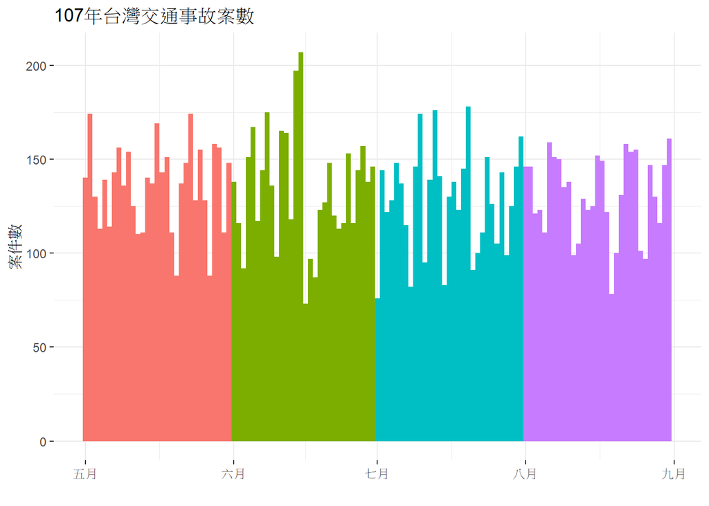

```r
ggplot()+geom_bar(data=s5,aes(x=date,y=case),stat = "identity",fill =hue_pal()(4)[1], width = 1)+geom_bar(data=s6,aes(x=date,y=case),stat = "identity",fill =hue_pal()(4)[2], width = 1)+geom_bar(data=s7,aes(x=date,y=case),stat = "identity",fill =hue_pal()(4)[3], width = 1)+geom_bar(data=s8,aes(x=date,y=case),stat = "identity",fill =hue_pal()(4)[4], width = 1)+labs(title="107年台灣交通事故案數",x="",y="案件數") +theme_bw()+theme(panel.border = element_blank())
```

- 9~12月案數

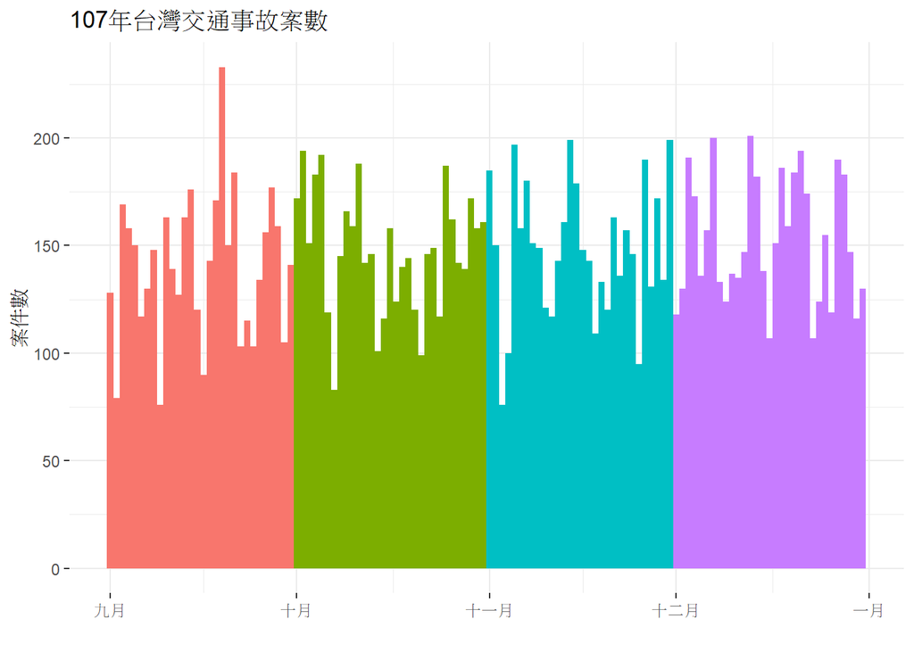

```r
ggplot()+geom_bar(data=s9,aes(x=date,y=case),stat = "identity",fill =hue_pal()(4)[1], width = 1)+geom_bar(data=s10,aes(x=date,y=case),stat = "identity",fill =hue_pal()(4)[2], width = 1)+geom_bar(data=s11,aes(x=date,y=case),stat = "identity",fill =hue_pal()(4)[3], width = 1)+geom_bar(data=s12,aes(x=date,y=case),stat = "identity",fill =hue_pal()(4)[4], width = 1)+labs(title="107年台灣交通事故案數",x="",y="案件數") +theme_bw()+theme(panel.border = element_blank())
```